# R Notebook

Load all the relevant packages

# Presentation of the shock series

Load the data

```r
save_path_esp <- 'C:/Users/DBT3KD/Desktop/Etude_macro_elec/prix_electricite_gitlab/Intra_day_instrumnet_motivation/outputs'
setwd(save_path_esp)
final_indispo <- read_parquet( 'final_indispo.parquet')

updated_non_duplicated_indispo <- read_parquet('updated_non_duplicated_indispo.parquet')

non_duplicated_indispo <- read_parquet('non_duplicated_indispo.parquet')


real_indispo_rf <- read_parquet('real_indispo_rf.parquet')

real_non_zero_previous_indispo <- read_parquet('real_non_zero_previous_indispo.parquet')

complete_data <- read_parquet('complete_indispo_data.parquet')
```

Some summary statistics on the shocks themselves

```r
summary_stat <- non_duplicated_indispo %>%
  mutate(hours_affected = as.numeric(last_affec_tim_period) - as.numeric(first_affec_tim_period),
         Fuel.Type = factor(Fuel.Type),
         duration = as.numeric(duration),
          Unavailable.Capacity = as.numeric( Unavailable.Capacity)
         ) %>%
  select(hours_affected, Fuel.Type,
         duration, Unavailable.Capacity, datetime_pub,
         electricity_delivery_date)
# summary_stat[, c()]

# Get summary statistics for the data frame
# Example usage with the built-in mtcars dataset
describe(summary_stat)
```

|  | vars | n | mean | sd | median | trimmed | mad | min | max | range | skew | kurtosis | se |
| --- | --- | --- | --- | --- | --- | --- | --- | --- | --- | --- | --- | --- | --- |
| hours_affected | 1 | 1110 | 3.48 | 8.04 | 3.00 | 3.54 | 4.45 | -24.00 | 23.00 | 47.00 | -0.47 | 2.07 | 0.24 |
| Fuel.Type* | 2 | 1110 | 4.90 | 2.32 | 4.00 | 4.79 | 2.97 | 1.00 | 12.00 | 11.00 | 0.40 | -0.94 | 0.07 |
| duration | 3 | 819 | 1.06 | 1.20 | 0.56 | 0.84 | 0.59 | 0.04 | 5.00 | 4.96 | 1.51 | 1.30 | 0.04 |
| Unavailable.Capacity | 4 | 1110 | 203.26 | 166.45 | 138.06 | 185.45 | 149.71 | 1.50 | 1063.94 | 1062.44 | 1.41 | 3.29 | 5.00 |
| datetime_pub | 5 | 1110 | NaN | NA | NA | NaN | NA | Inf | -Inf | -Inf | NA | NA | NA |
| electricity_delivery_date* | 6 | 1110 | 240.66 | 125.13 | 264.50 | 244.96 | 149.00 | 1.00 | 433.00 | 432.00 | -0.26 | -1.18 | 3.76 |

```r
# Charger le package patchwork pour combiner les graphiques
library(patchwork)
library(cowplot)
library(gridExtra)
library(grid)
library(latex2exp)
library(ggplot2)
non_duplicated_indispo$year <- year(non_duplicated_indispo$datetime_pub)
updated_non_duplicated_indispo <- updated_non_duplicated_indispo %>%
  mutate(datetime_pub = as.POSIXct(paste(electricity_delivery_date, creneau-1)
              , format="%Y-%m-%d %H", tz = 'UTC'),
         year = year(datetime_pub))


updated_plot_data <- updated_non_duplicated_indispo %>%
  select(datetime_pub, real_unavailability, Fuel.Type, year) %>%
  group_by(year, Fuel.Type) %>%
  summarise(real_unavailability.mean = mean(as.numeric(real_unavailability)),
         n_indispo = n())
```

[output not shown]

```r
plot_data <- non_duplicated_indispo %>%
  select(datetime_pub, Unavailable.Capacity, Fuel.Type, year) %>%
  group_by(year, Fuel.Type) %>%
  summarise(Unavailable.Capacity.mean = mean(as.numeric(Unavailable.Capacity)),
         n_indispo = n()) %>%
  filter(Fuel.Type %in% updated_plot_data$Fuel.Type)
```

[output not shown]

```r
# Premier graphique: Unavailable Capacity par Fuel Type
plot1 <- ggplot() +
  geom_bar(data = plot_data, aes(x = as.factor(year), y = Unavailable.Capacity.mean, fill = Fuel.Type), alpha=0.4,
           stat = "identity", position = "dodge") +

  geom_bar(data = updated_plot_data, aes(x = as.factor(year), y = real_unavailability.mean, fill = Fuel.Type),
           stat = "identity", position = "dodge") +

  labs(x = 'Date de publication', y = "Unavailable Capacity") +
  theme_minimal()

custom_legend <- cowplot::get_legend(plot1)
plot1 <-plot1 +
  theme(legend.position = "none")

# Deuxième graphique: Nombre d'indisponibilités (n_indispo)
plot2 <- ggplot() +
  geom_bar(data = plot_data, aes(x = as.factor(year), y = -n_indispo, fill = Fuel.Type), alpha=0.4,
           stat = "identity", position = "dodge") +
  geom_bar(data = updated_plot_data, aes(x = as.factor(year), y = -n_indispo, fill = Fuel.Type),
           stat = "identity", position = "dodge") +
  labs(y = "Nombre d\'indisponibilités") +
  theme_minimal()+
  theme(axis.title.x = element_blank(), # Désactiver le titre de l'axe des x
        axis.text.x = element_blank(),
        legend.position = "none")  # Désactiver les ticks de l'axe des x
  # Ajouter un titre personnalisé comme annotation
  #+annotate("text", x = Inf, y = -Inf, label = "Number of Power Outages",
           #hjust = 1.4, vjust = -1.5, size = 5)
# Assembler les deux graphiques verticalement avec patchwork
combined_plot <- plot1 / plot2 #+ draw_plot(custom_legend, x = 0.8, y = 0.5, width = 0.2, height = 0.5)
```

|  | t | l | b | r |
| --- | --- | --- | --- | --- |
| 1: | 1 | 1 | 1 | 1 |
| 2: | 1 | 2 | 1 | 2 |

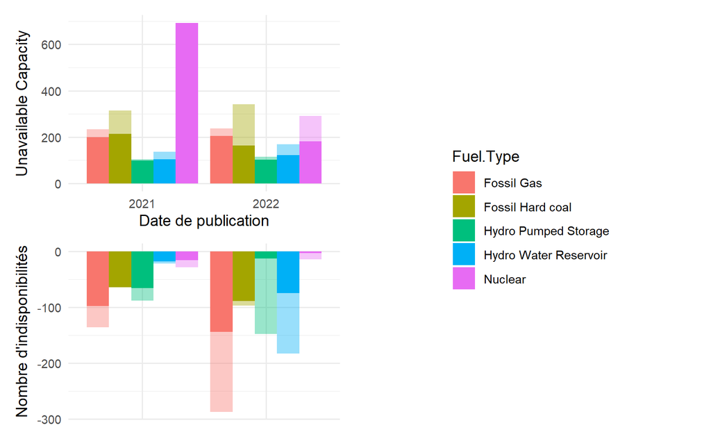

```r
# Combine the grid with the legend
final_plot <- plot_grid(combined_plot, custom_legend ,
                        ncol = 2, rel_heights = c(1, 0.1))



# Afficher le graphique combiné
final_plot
```

Deuxième graphique avec la méthode de prévision par random forest

```r
real_plot_pred_data <- real_indispo_rf %>%
  mutate(year=year(datetime)) %>%
  distinct(predicted_real_unavailability, name, year, Fuel.Type) %>%
  group_by(year, Fuel.Type) %>%
  summarise(predicted_real_unavailability.mean = mean(as.numeric(predicted_real_unavailability)),
         n_indispo = n())
```

[output not shown]

```r
plot_data <- plot_data %>%
  filter(Fuel.Type %in% real_plot_pred_data$Fuel.Type)

updated_plot_data <- updated_plot_data %>%
  filter(Fuel.Type %in% real_plot_pred_data$Fuel.Type)
```

On combine toutes les informations sur un même graphique

```r
# Premier graphique: Unavailable Capacity par Fuel Type
plot1 <- ggplot() +
  geom_bar(data = plot_data, aes(x = as.factor(year), y = Unavailable.Capacity.mean, fill = Fuel.Type), alpha=0.4,
           stat = "identity", position = "dodge") +

  geom_bar(data = updated_plot_data, aes(x = as.factor(year), y = real_unavailability.mean, fill = Fuel.Type),
           stat = "identity", position = "dodge",alpha=0.8, color= 'black' )
plot1 <- plot1 +
  geom_point(data= real_plot_pred_data, mapping = aes(x = as.factor(year), y = -predicted_real_unavailability.mean, color = Fuel.Type), size = 3, position = position_dodge(width = 0.85)) +
  # Ajouter des points pour la moyenne et espacer
  geom_linerange(data= real_plot_pred_data,
                 aes(x= as.factor(year),
      ymin = 0, ymax = -predicted_real_unavailability.mean, color = Fuel.Type),
                 size = 1,
                 position = position_dodge(width = 0.85)) +
    labs(x = 'Date de publication', y = "Unavailable Capacity") +
  theme_minimal()
custom_legend <- cowplot::get_legend(plot1)
plot1 <-plot1 +
  theme(legend.position = "none")

# Deuxième graphique: Nombre d'indisponibilités (n_indispo)
plot2 <- ggplot() +
  geom_bar(data = plot_data, aes(x = as.factor(year), y = -n_indispo, fill = Fuel.Type), alpha=0.4,
           stat = "identity", position = "dodge") +
  geom_bar(data = updated_plot_data, aes(x = as.factor(year), y = -n_indispo, fill = Fuel.Type),
           stat = "identity", position = "dodge",alpha=0.8, color= 'black') +
  labs(y = "Nombre d\'indisponibilités") +
  theme_minimal() # Désactiver les ticks de l'axe des x


plot2 <- plot2 +
  geom_point(data= real_plot_pred_data, mapping = aes(x = as.factor(year), y = -n_indispo, color = Fuel.Type), size = 3, position = position_dodge(width = 0.85)) +
  # Ajouter des points pour la moyenne et espacer
  geom_linerange(data= real_plot_pred_data,
                 aes(x= as.factor(year),
      ymin = 0, ymax = -n_indispo, color = Fuel.Type),
                 size = 1,
                 position = position_dodge(width = 0.85)) +

  theme_minimal()+
  theme(axis.title.x = element_blank(), # Désactiver le titre de l'axe des x
        axis.text.x = element_blank(),
        legend.position = "none")

  # Ajouter un titre personnalisé comme annotation
  #+annotate("text", x = Inf, y = -Inf, label = "Number of Power Outages",
           #hjust = 1.4, vjust = -1.5, size = 5)
# Assembler les deux graphiques verticalement avec patchwork
combined_plot <- plot1 / plot2 #+ draw_plot(custom_legend, x = 0.8, y = 0.5, width = 0.2, height = 0.5)
```

|  | t | l | b | r |
| --- | --- | --- | --- | --- |
| 1: | 1 | 1 | 1 | 1 |
| 2: | 1 | 2 | 1 | 2 |

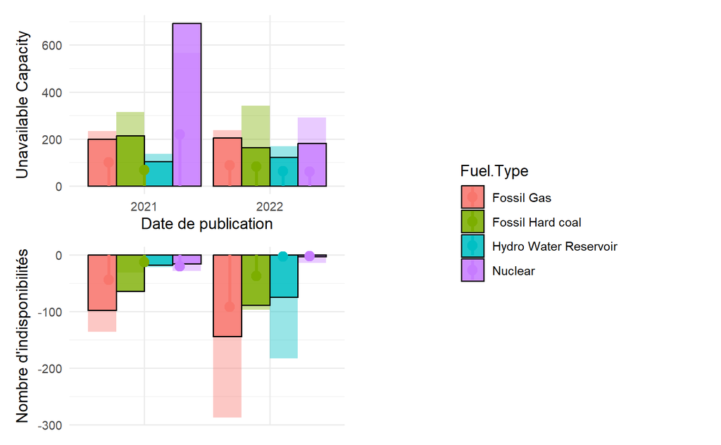

```r
# Combine the grid with the legend
final_plot <- plot_grid(combined_plot, custom_legend ,
                        ncol = 2, rel_heights = c(1, 0.1))



# Afficher le graphique combiné
final_plot
```

```r
NA
NA
```

Je peux faire une légende des formes

On plotte maintenant les séries en question

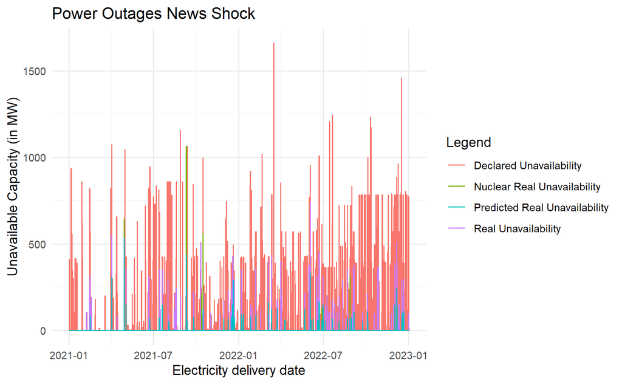

```r
my_plot <- ggplot(data = complete_data) +
  geom_line(aes(x = datetime, y = Unavailable.Capacity, color = "Declared Unavailability")) +
  geom_line(aes(x = datetime, y = real_unavailability, color = "Real Unavailability")) +
  geom_line(aes(x = datetime, y = nuclear_real_unavailability, color = "Nuclear Real Unavailability")) +
  geom_line(aes(x = datetime, y = -predicted_real_unavailability, color = "Predicted Real Unavailability")) +
  labs(
    x = 'Electricity delivery date',
    y = "Unavailable Capacity (in MW)",
    title = "Power Outages News Shock",
    color = "Legend"  # Label for the legend
  ) +
  theme_minimal()

my_plot
```

Nota bene: it could depend on whether this plant was supposed to generate electricity, maybe get the generation schedule, to deduce which have low marginal cost, maybe it depends from fuel type and whether or not ‘pilotable’

This magnitude is rather small. Yet, we expect that the price setting mechanism of marginal pricing will have a substantial (and maybe discontinuous) impact on prices by forcing a new high-cost unit to produce on the market.

```r
setwd('C:/Users/nchu/Desktop/DATA/power-plant/IIP_indispo')
write_parquet(complete_data, 'completed_shock_series.parquet')
```

# Renewable intermittence shock serie

Load associated data

```r
save_path_esp <- 'C:/Users/DBT3KD/Desktop/Etude_macro_elec/prix_electricite_gitlab/Intra_day_instrumnet_motivation/outputs'
setwd(save_path_esp)
renewable_shock_series <- read_parquet(
              'renewable_forecasts.parquet')
```

Get some summary statistics

```r
# some summary stat
describe(renewable_shock_series)
```

|  | vars | n | mean | sd | median | trimmed | mad | min | max | range | skew | kurtosis | se |
| --- | --- | --- | --- | --- | --- | --- | --- | --- | --- | --- | --- | --- | --- |
| __index_level_0__ | 1 | 33400 | NaN | NA | NA | NaN | NA | Inf | -Inf | -Inf | NA | NA | NA |
| Fore_Wind | 2 | 33400 | 3557.98 | 4338.10 | 626.0 | 2941.52 | 923.66 | 0 | 13980 | 13980 | 0.88 | -0.77 | 23.74 |
| Fore_Solar | 3 | 33400 | 6533.23 | 3590.64 | 5868.5 | 6206.13 | 3578.26 | 407 | 19472 | 19065 | 0.80 | 0.26 | 19.65 |
| Intraday_Fore_Wind | 4 | 33400 | 3566.87 | 4352.77 | 634.0 | 2948.60 | 938.49 | 0 | 13973 | 13973 | 0.88 | -0.78 | 23.82 |
| Intraday_Fore_Solar | 5 | 33400 | 6580.46 | 3567.28 | 5989.5 | 6278.49 | 3647.94 | 394 | 19334 | 18940 | 0.73 | 0.10 | 19.52 |
| gen_tot | 6 | 33400 | 30348.02 | 4786.97 | 30212.0 | 30282.03 | 5147.59 | 18672 | 44988 | 26316 | 0.12 | -0.54 | 26.19 |
| gen_uncontrolled | 7 | 33400 | 10848.33 | 4968.21 | 10392.0 | 10639.89 | 5680.58 | 1069 | 26951 | 25882 | 0.34 | -0.62 | 27.18 |
| Solar | 8 | 33400 | 3519.33 | 4327.97 | 676.0 | 2895.00 | 990.38 | 0 | 14314 | 14314 | 0.90 | -0.73 | 23.68 |
| Wind Onshore | 9 | 33400 | 6552.62 | 3695.73 | 5936.0 | 6230.86 | 3737.63 | 181 | 20200 | 20019 | 0.75 | 0.13 | 20.22 |
| Wind Offshore | 10 | 33400 | 0.00 | 0.00 | 0.0 | 0.00 | 0.00 | 0 | 0 | 0 | NaN | NaN | 0.00 |

[output cut: 4 more lines]

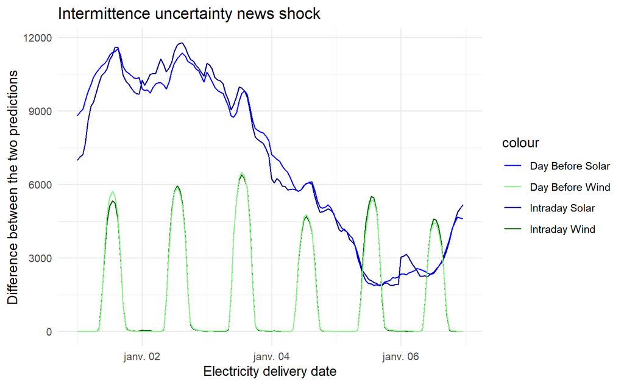

```r
date_time_string <- "2021/01/07 00:00:00"

# Convert to POSIXct
posixct_date_time <- as.POSIXct(date_time_string, format = "%Y/%m/%d %H:%M:%S")

renewable_shock_first_week <- renewable_shock_series%>%
  rename(datetime =`__index_level_0__`) %>%
  filter(datetime < posixct_date_time )

my_plot <- ggplot(data =renewable_shock_first_week)+
  geom_line(aes(x =datetime , y = Intraday_Fore_Solar, color="Intraday Solar")) +
geom_line(aes(x =datetime , y = Fore_Solar, color="Day Before Solar")) +
  geom_line(aes(x =datetime , y = Intraday_Fore_Wind, color="Intraday Wind")) +
  geom_line(aes(x =datetime , y = Fore_Wind, color="Day Before Wind")) +
  labs(x= 'Electricity delivery date', y = "Difference between the two predictions",
       title = "Intermittence uncertainty news shock") +
  scale_color_manual(values = c("Intraday Solar" = "darkblue", "Day Before Solar" = "blue", "Intraday Wind" = "darkgreen", "Day Before Wind" = "lightgreen")) +
  theme_minimal()

my_plot
```

```r
library(tidyverse)
colnames(renewable_shock_series)
# print(class(plot_data$electricity_delivery_date))

my_plot <- ggplot(renewable_shock_series, aes(x =datetime , y = uncertainty_shock)) +
  geom_line(stat = "identity", position = "dodge") +
  labs(x= 'Electricity delivery date', y = "Difference between the two predictions",
       title = "INtermittence uncertainty news shock") +
  theme_minimal()

my_plot
```

[output not shown]

# Presentation of the price series

```r
getwd()
```

```
[1] "C:/Users/DBT3KD/Desktop/Etude_macro_elec/prix_electricite_gitlab/Intra_day_instrumnet_motivation"
```

```r
auction_path <- 'C:/Users/DBT3KD/Desktop/Etude_macro_elec/DATA/intra_day_prices/OMIE-auction-market-data'
setwd(auction_path)
price_data <- read_parquet('auction_price_data_21_22.parquet')
price_data$price <- as.numeric(price_data$price)
```

The 7 auctions can give rise to different price series.

Let’s look at it first on a single day window

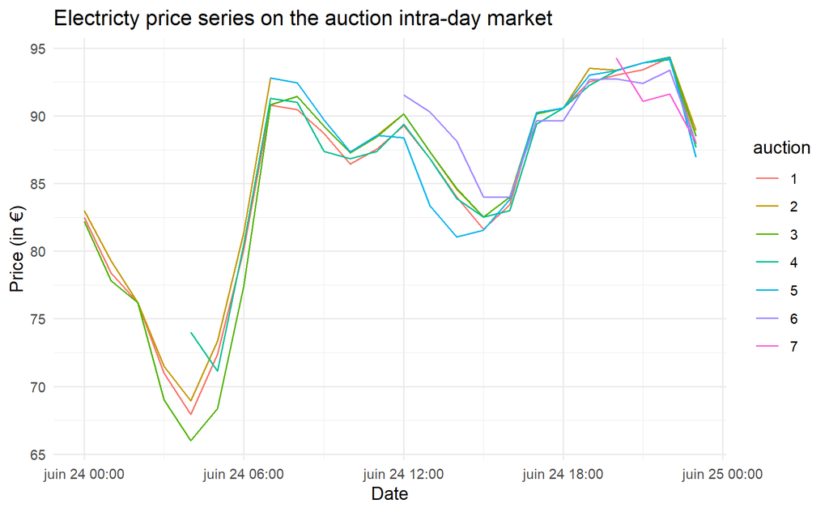

```r
price_data_2021_09_09 <- price_data %>%
  filter(year=='2021' & month=='6' & day == '24')

my_plot <- ggplot(price_data_2021_09_09, aes(x =datetime , y = price, color= auction)) +
  geom_line() +
  labs(x= 'Date', y = "Price (in €)",
       title = "Electricty price series on the auction intra-day market") +
  theme_minimal()

my_plot
```

This is an overview of what it looks like on the whole time span

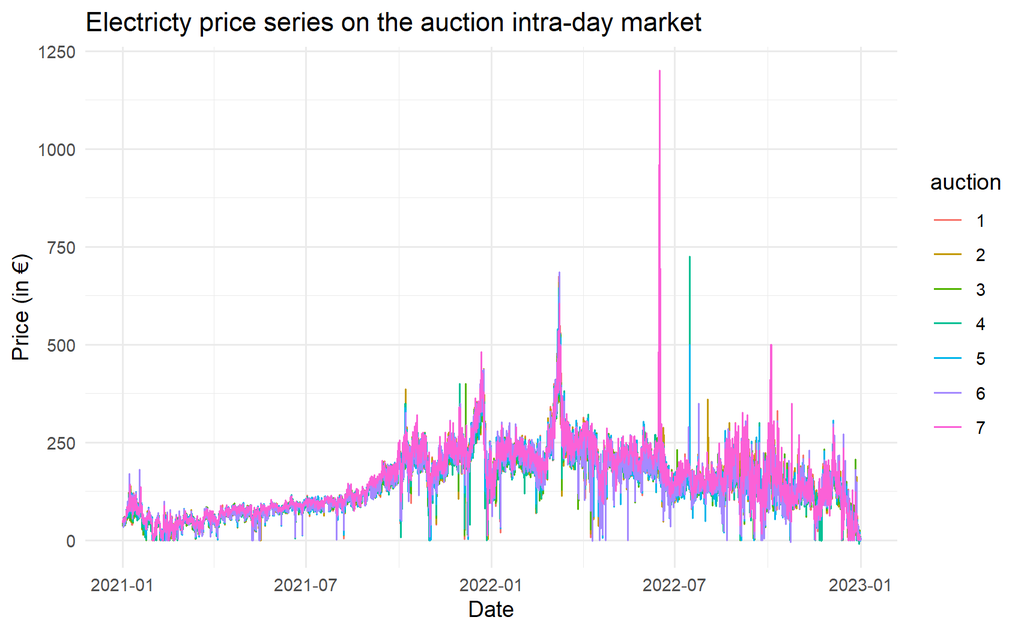

```r
# rm(auction, envir = .GlobalEnv)
my_plot <- ggplot(price_data, aes(x =datetime , y = price, color= auction)) +
  geom_line() +
  labs(x= 'Date', y = "Price (in €)",
       title = "Electricty price series on the auction intra-day market") +
  theme_minimal()

my_plot
```